# Temperature in America from 1960 to 2014

Layne West

5-10-2019

### Data overview

The data that was used in this report was the latitude and longitude of many points across the Earth’s surface. Each point had correlated with it a time (for example, 1960-01-01), precipitation, and temperature. In this report, I narrowed the observations down to only those observations in April of 1960, 1986, and 2014. Furthermore, I focused only on temperature and not precipitation. Temperature is represented by the monthly mean in Celsius.

### The graphs

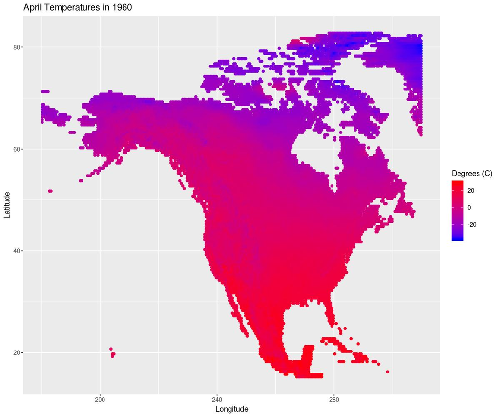

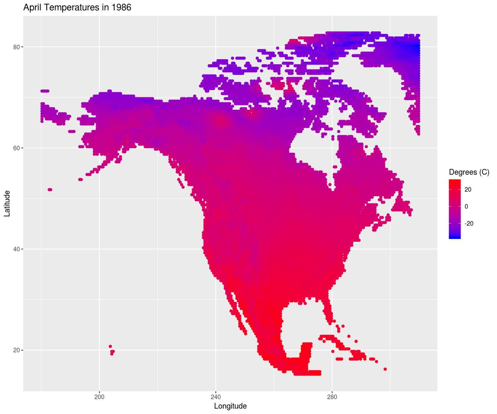

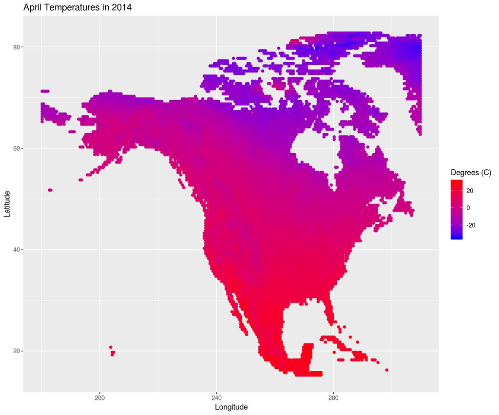